# Geospatial_final

Oliver Gatland

2024-03-27

## Geospatial Final project

### Oliver Gatland, Luis Francisco Alvarez, Richard O’Shea

#### In this markdown file we include all the code used for our Geospatial final project. Please see the accompanying write up for more detailed explanations of the research.

## Data preparation - distance variable

```r
# Load data
sf.cities<-st_read("C:/Users/gatla/OneDrive/BSE/Geospatial/homework/homework3/ne_10m_populated_places/ne_10m_populated_places.shp")
# Countries to remove - non Sub Saharan countries or never eligible for AGOA
remove_names <-c("Libya","Tunisia","Algeria","Eritrea","Morocco","Egypt","Sudan","Somalia")

# Countries to include
maritime <-c("Sudan", "Djibouti","Eritrea","Kenya", "United Republic of Tanzania","South Africa", "Namibia","Angola","Gabon","Congo (Brazzaville)","Cameroon","Nigeria","Benin","Togo","Ghana","Ivory Coast","Liberia","Sierra Leone","Guinea", "Guinea Bissau", "Senegal", "Mauritania")
```

```r
# Country level data on Africa adjusting some country names
sf.Africa <-world%>%
  filter(continent=='Africa')%>%
  mutate(name_long = case_when(
    name_long == "Tanzania" ~ "United Republic of Tanzania",
    TRUE ~ name_long
  ))%>%
  mutate(name_long = case_when(
    name_long == "Guinea-Bissau" ~ "Guinea Bissau",
    TRUE ~ name_long
  ))%>%
  mutate(name_long = case_when(
    name_long == "Republic of the Congo" ~ "Congo (Brazzaville)",
    TRUE ~ name_long
  ))%>%
  mutate(name_long = case_when(
    name_long == "Côte d'Ivoire" ~ "Ivory Coast",
    TRUE ~ name_long
  ))%>%
  mutate(name_long = case_when(
    name_long == "The Gambia" ~ "Gambia, The",
    TRUE ~ name_long
  ))
```

```r
# Subset populated places data to Africa, this was necessary as cities did not have a country variable
sf.africa_cities <- st_intersection(sf.cities,sf.Africa)%>%
  dplyr::select(NAME,POP_MAX,SOV0NAME,name_long)
# Load road data adjusting country names and standardising link roads
sf.roads <- st_read("C:/Users/gatla/OneDrive/BSE/Geospatial/Final_project/AFR_Infra_Transport_Road.shp/AFR_Infra_Transport_Road.shp")%>%
  mutate(Country = case_when(
    Country == "Tanzania" ~ "United Republic of Tanzania",
    TRUE ~ Country # Keeps the original value if the condition above is not met
  ))%>%
  mutate(Country = case_when(
    Country == "Guinea-Bissau" ~ "Guinea Bissau",
    TRUE ~ Country # Keeps the original value if the condition above is not met
  ))%>%
  mutate(Country = case_when(
    Country == "Côte d’Ivoire" ~ "Ivory Coast",
    TRUE ~ Country # Keeps the original value if the condition above is not met
  ))%>%
  mutate(Country = case_when(
    Country == "Senegal and The Gambia" ~ "Senegal",
    TRUE ~ Country # Keeps the original value if the condition above is not met
  ))%>%
  mutate(FeatureTyp = case_when(
    FeatureTyp == "Road (Motorway Link)" ~ "Road (Motorway)",
    TRUE ~ FeatureTyp # Keeps the original value if the condition above is not met
  ))%>%
  mutate(FeatureTyp = case_when(
    FeatureTyp == "Road (Trunk Link)" ~ "Road (Trunk)",
    TRUE ~ FeatureTyp # Keeps the original value if the condition above is not met
  ))%>%
  mutate(FeatureTyp = case_when(
    FeatureTyp == "Road (Primary Link)" ~ "Road (Primary)",
    TRUE ~ FeatureTyp # Keeps the original value if the condition above is not met
  ))%>%
  mutate(FeatureTyp = case_when(
    FeatureTyp == "Road (Secondary Link)" ~ "Road (Secondary)",
    TRUE ~ FeatureTyp # Keeps the original value if the condition above is not met
  ))
```

```r
#Load ports as point data and with a buffer. The buffer was necessary as ports did not have a country and the buffer allowed us to identify the country for ports slightly away from the coast on them map
sf.africa_ports_point<- st_read("C:/Users/gatla/OneDrive/BSE/Geospatial/Final_project/ne_10m_ports/ne_10m_ports.shp")%>%
  st_crop(sf.Africa)
sf.africa_ports_buff <- st_read("C:/Users/gatla/OneDrive/BSE/Geospatial/Final_project/ne_10m_ports/ne_10m_ports.shp")%>%
  st_crop(sf.Africa)%>%
  st_buffer(dist=20000)
# Join ports data based on name from Africa data
sf.Africa_names <-sf.Africa%>%
  dplyr::select(name_long)
sf.africa_ports_buffed<-st_join(sf.africa_ports_buff,sf.Africa_names)%>%
  st_drop_geometry()
sf.africa_ports<-st_join(sf.africa_ports_point,sf.Africa_names)

sf.africa_port_final<-sf.africa_ports%>%
  left_join(sf.africa_ports_buffed,by = "ne_id")%>%
  dplyr::select(name.y,name_long.y)%>%
  rename(name_long=name_long.y)

rm(sf.africa_ports_buffed)
rm(sf.africa_ports_point)
rm(sf.africa_ports_buff)

# Add empty dataframe to store distance data
results_sf <- st_sf(city=character(), country=character(), min_dist=numeric(), geometry=st_sfc(), crs=4326)
```

```r
# Set up directory to save plots
plots_dir <- "plots_weight_agoa"
dir.create(plots_dir)
```

Loop through each country and find the shortest distance between the cities and the nearest port within the same country.

```
## [1] "Sudan"
```

```
## [1] 1
```

```
## [1] 2
## [1] 3
## [1] 4
## [1] 5
## [1] 6
## [1] 7
## [1] 8
## [1] 9
## [1] 10
## [1] 11
## [1] 12
## [1] 13
## [1] 14
## [1] 15
## [1] 16
## [1] 17
## [1] 18
## [1] 19
## [1] 20
## [1] 21
## [1] 22
## [1] 23
## [1] 24
## [1] 25
## [1] 26
## [1] 27
## [1] 28
## [1] 29
```

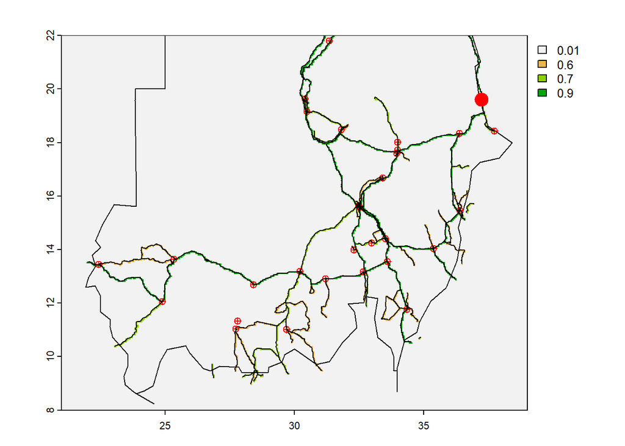

```
## [1] "Djibouti"
```

```
## [1] 1
## [1] 2
```

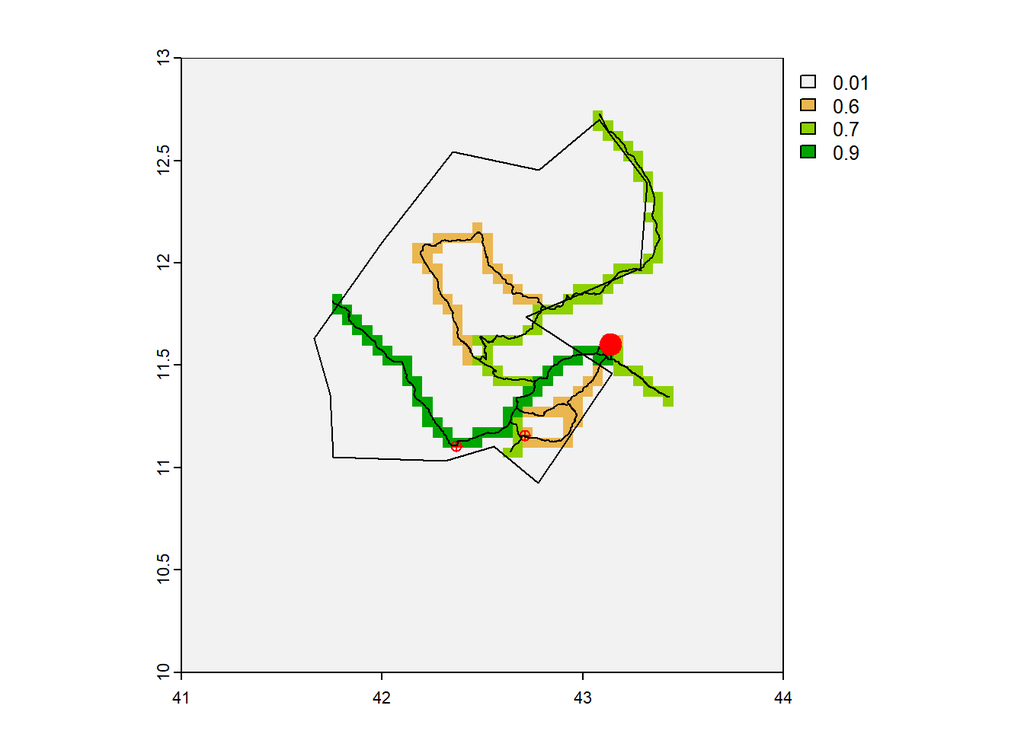

```
## [1] "Eritrea"
```

```
## [1] 1
## [1] 2
## [1] 3
## [1] 4
## [1] 5
## [1] 6
```

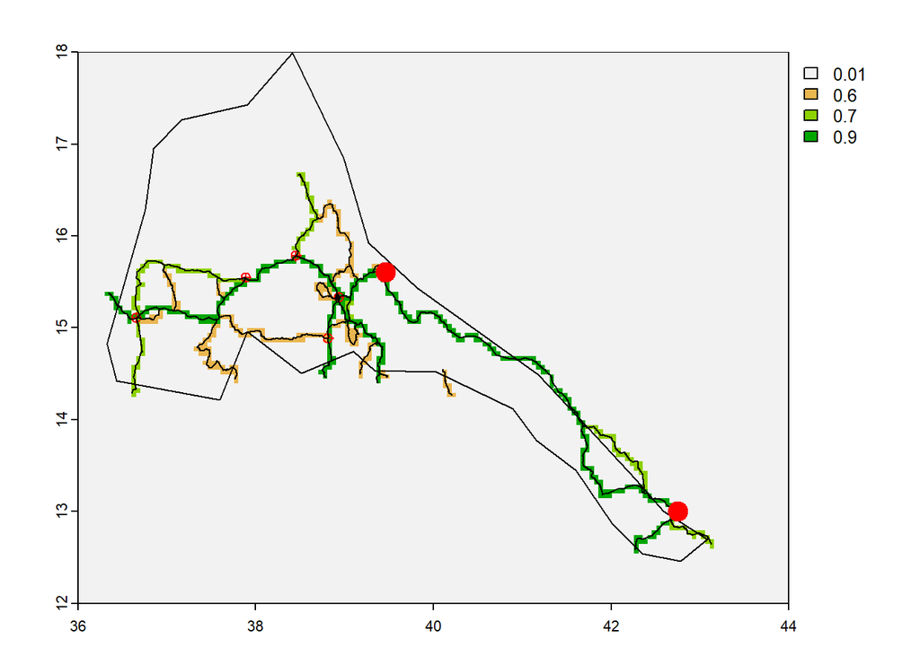

```
## [1] "Kenya"
```

```
## [1] 1
## [1] 2
## [1] 3
## [1] 4
## [1] 5
## [1] 6
## [1] 7
## [1] 8
## [1] 9
## [1] 10
## [1] 11
## [1] 12
## [1] 13
## [1] 14
## [1] 15
```

[output cut: 19 more lines]

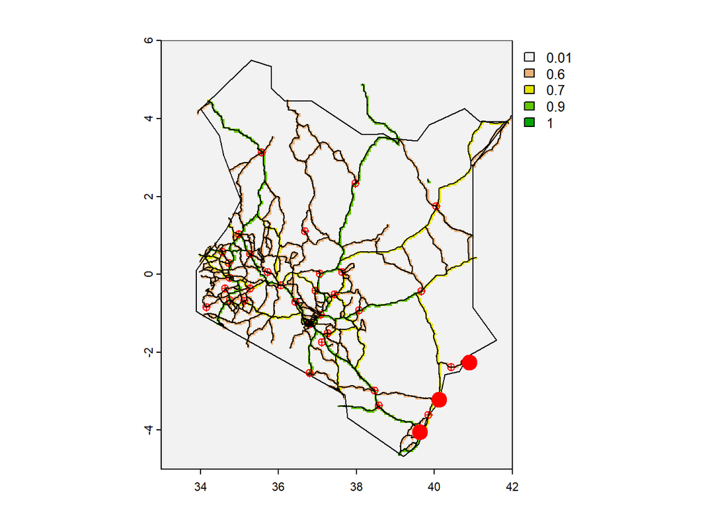

```
## [1] "United Republic of Tanzania"
```

```
## [1] 1
## [1] 2
## [1] 3
## [1] 4
## [1] 5
## [1] 6
## [1] 7
## [1] 8
## [1] 9
## [1] 10
## [1] 11
## [1] 12
## [1] 13
## [1] 14
## [1] 15
```

[output cut: 36 more lines]

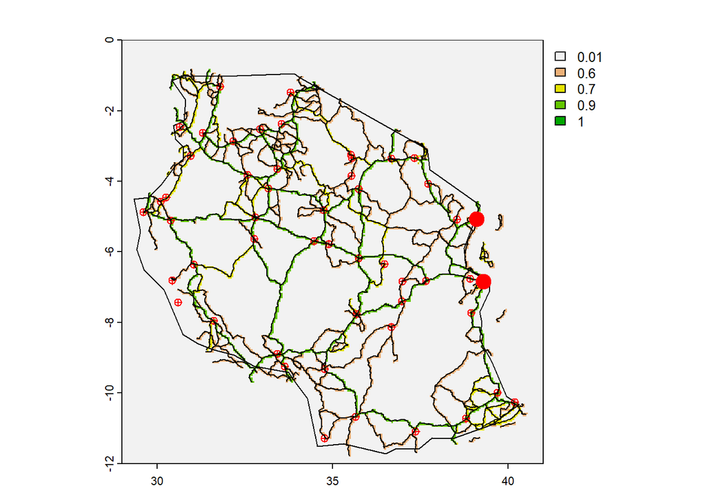

```
## [1] "South Africa"
```

```
## [1] 1
## [1] 2
## [1] 3
## [1] 4
## [1] 5
## [1] 6
## [1] 7
## [1] 8
## [1] 9
## [1] 10
## [1] 11
## [1] 12
## [1] 13
## [1] 14
## [1] 15
```

[output cut: 51 more lines]

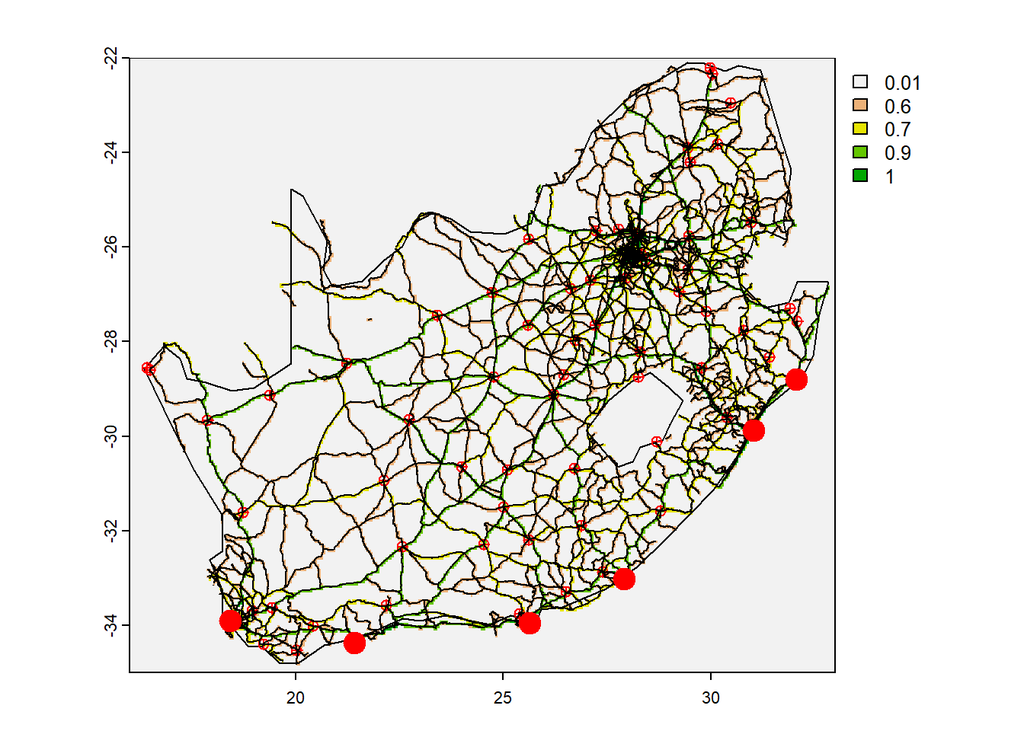

```
## [1] "Namibia"
```

```
## [1] 1
## [1] 2
## [1] 3
## [1] 4
## [1] 5
## [1] 6
## [1] 7
## [1] 8
## [1] 9
## [1] 10
## [1] 11
## [1] 12
## [1] 13
## [1] 14
## [1] 15
## [1] 16
## [1] 17
## [1] 18
## [1] 19
## [1] 20
## [1] 21
## [1] 22
## [1] 23
## [1] 24
## [1] 25
## [1] 26
## [1] 27
## [1] 28
## [1] 29
```

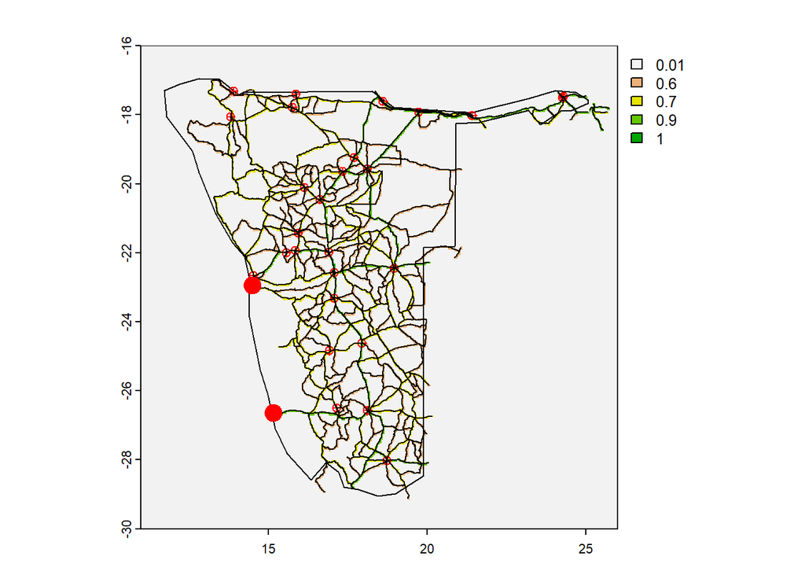

```
## [1] "Angola"
```

```
## [1] 1
## [1] 2
## [1] 3
## [1] 4
## [1] 5
## [1] 6
## [1] 7
## [1] 8
## [1] 9
## [1] 10
## [1] 11
## [1] 12
## [1] 13
## [1] 14
## [1] 15
```

[output cut: 31 more lines]

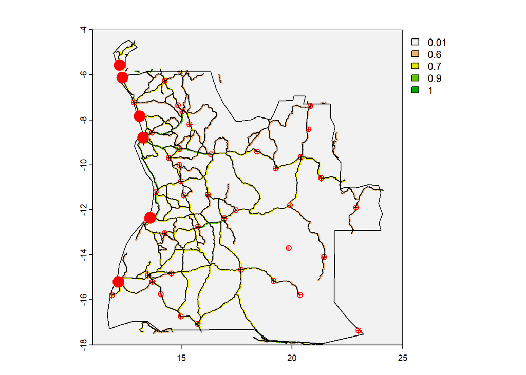

```
## [1] "Gabon"
```

```
## [1] 1
## [1] 2
## [1] 3
## [1] 4
## [1] 5
## [1] 6
## [1] 7
## [1] 8
## [1] 9
## [1] 10
## [1] 11
## [1] 12
## [1] 13
## [1] 14
## [1] 15
## [1] 16
## [1] 17
## [1] 18
## [1] 19
## [1] 20
```

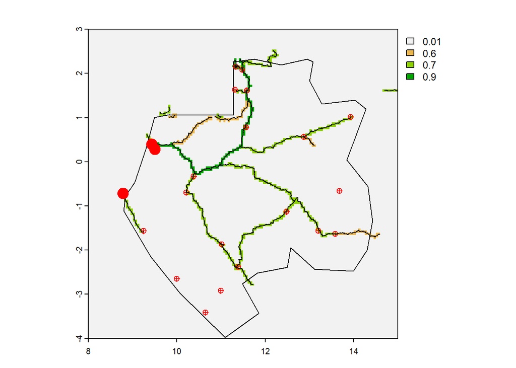

```
## [1] "Congo (Brazzaville)"
```

```
## [1] 1
## [1] 2
## [1] 3
## [1] 4
## [1] 5
## [1] 6
## [1] 7
## [1] 8
## [1] 9
## [1] 10
## [1] 11
## [1] 12
## [1] 13
## [1] 14
```

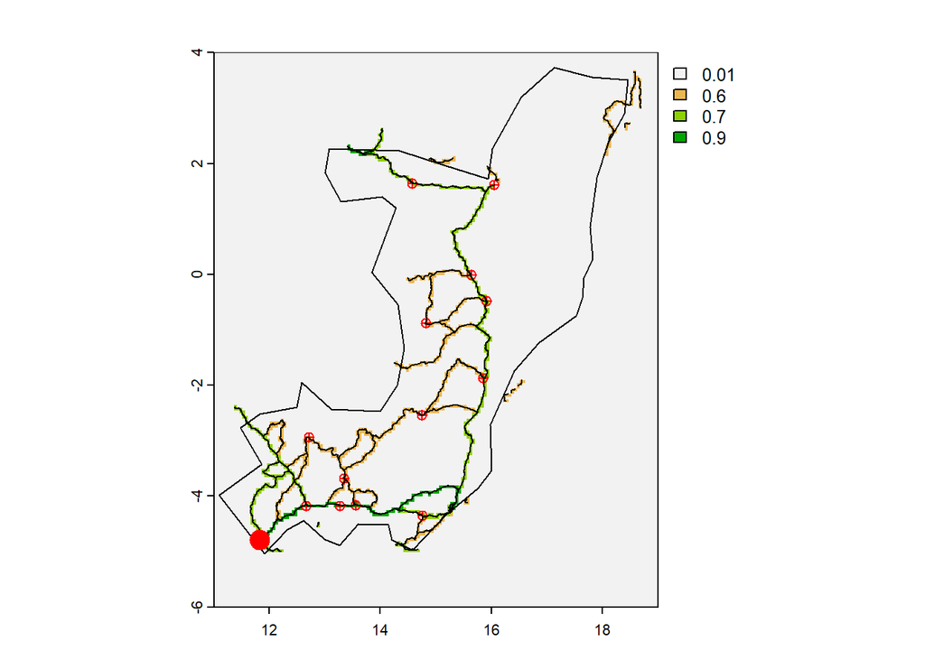

```
## [1] "Cameroon"
```

```
## [1] 1
## [1] 2
## [1] 3
## [1] 4
## [1] 5
## [1] 6
## [1] 7
## [1] 8
## [1] 9
## [1] 10
## [1] 11
## [1] 12
## [1] 13
## [1] 14
## [1] 15
```

[output cut: 17 more lines]

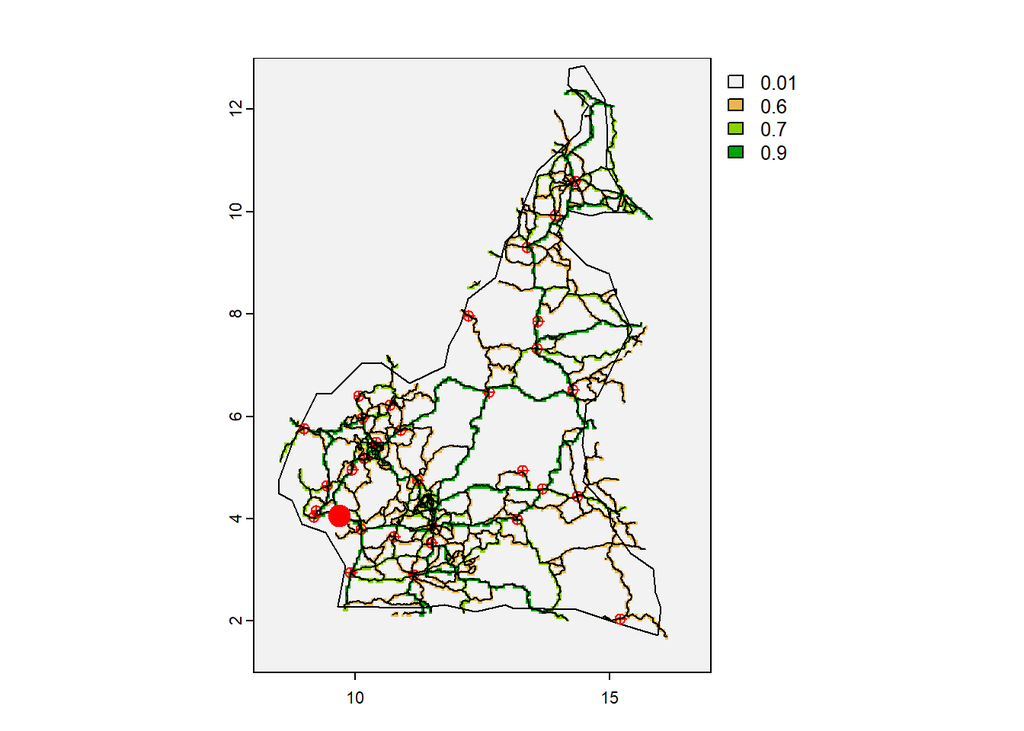

```
## [1] "Nigeria"
```

```
## [1] 1
## [1] 2
## [1] 3
## [1] 4
## [1] 5
## [1] 6
## [1] 7
## [1] 8
## [1] 9
## [1] 10
## [1] 11
## [1] 12
## [1] 13
## [1] 14
## [1] 15
```

[output cut: 54 more lines]

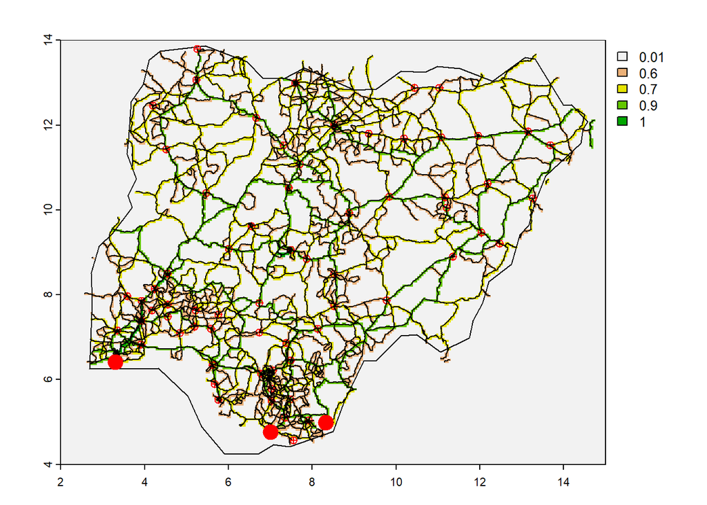

```
## [1] "Benin"
```

```
## [1] 1
## [1] 2
## [1] 3
## [1] 4
## [1] 5
## [1] 6
## [1] 7
## [1] 8
## [1] 9
```

[10 more figures not shown]

```r
for (c in maritime) {
  print(c)


  sf.port<-sf.africa_port_final%>%filter(name_long==c)
  sf.city<-sf.africa_cities%>%filter(name_long==c)
  sf.road<-sf.roads%>%filter(Country==c)
  sf.country <-sf.Africa%>%filter(name_long==c)

  #Creating an empty raster with same extent as our country's shapefile
  r.blank_master <- rast()%>%
    project("EPSG:4326")%>% #specifies the CRS of the raster
    crop(sf.country,extend=TRUE,snap="out") #snap='out' ensures the extent covers the entire country, without this some cities were being cut off
  res(r.blank_master)<-0.05#setting the resolution to a reasonable amount. Smaller values can cause very long computation times

  #A loop which creates an intermediate empty raster as before and then adds the road shapefile, by road type, assigning a different value
  for (i in unique(sf.road$FeatureTyp)) {
    sf.int_road <- sf.road%>%filter(FeatureTyp==i)
    r.blank <- rast()%>%
      project("EPSG:4326")%>% #had to use this specific
      crop(sf.country,extend=TRUE,snap="out")
    res(r.blank)<-0.05
    r.int_rast <- rasterize(vect(sf.int_road),r.blank) #creating the raster with the road network from the blank raster
    vv<-values(r.int_rast)

    #Assigning the values - chosen intuitively to reflect differences in road quality
    if (i== "Road (Motorway)") {
      vv[!is.na(vv)] <- 1
    } else if (i== "Road (Trunk)") {
      vv[!is.na(vv)] <- 0.9
    } else if (i== "Road (Primary)") {
      vv[!is.na(vv)] <- 0.7
    } else if (i== "Road (Secondary)") {
      vv[!is.na(vv)] <- 0.6
    }

    values(r.int_rast) <- vv
    r.blank_master<-merge(r.blank_master,r.int_rast) #This then adds the intermediate rasters to the original, recreating the entire road network but with different values

  }
  master_vals <-values(r.blank_master)
  master_vals[is.na(master_vals)]<-0.01
  values(r.blank_master)<-master_vals

  tr.matrix <- transition(
    x = raster::raster(r.blank_master), #now the transition matrix accounts for different road types
    transitionFunction = mean,
    directions = 8
  )

  plot(r.blank_master)
  plot(sf.country$geom,add=TRUE)
  plot(sf.city$geometry,col="red",pch=10,add=TRUE)
  plot(sf.road$geometry,colour="green",add=TRUE)
  plot(sf.port$geometry, col = "red", pch = 19, cex = 2, add = TRUE)

  #A loop which the path for each city to each port, saving only the path to the most easily accessible port
  for (i in 1:nrow(sf.city)) {
    print(i)
    int_sf <- st_sf(city=character(), country=character(), min_dist=numeric(), geometry=st_sfc(), crs=4326)
    for (j in 1:nrow(sf.port)) {
      start <- as_Spatial(sf.city[i,]) #cities must be saved as spatial points for the shortestPath function
      end <- as_Spatial(sf.port[j,])
      costPath <- shortestPath(x=tr.matrix, origin=start, goal=end, output="SpatialLines") #this function finds the shortest path between two points based off a transition matrix, which is based off our road raster
      crs(costPath) <- CRS("+init=epsg:4326") #we project the raster before converting to a linestring. This ensures our projection is correct and our units are metres
      distance_1 <- st_as_sf(costPath)
      distance<-st_length(distance_1)
      name <- sf.city$NAME[i]
      country<-c
      int_row_sf <- st_sf(city=name, country=country, min_dist=distance, geometry=st_sfc(st_as_sfc(distance_1)), crs=4326)
      int_sf <- rbind(int_sf, int_row_sf)
    }
    row_with_min_dist <- int_sf %>%
      slice_min(order_by = min_dist, n = 1)

    # Append to the results sf dataframe
    results_sf <- rbind(results_sf, row_with_min_dist)

  }
  sf.country_result<-results_sf%>%filter(country==c)

  #saving our plots
  p<-ggplot()+
    geom_sf(data=sf.country)+
    geom_sf(data=sf.country_result,colour="red")+
    geom_sf(data=sf.road,colour="grey80",aes(linetype=FeatureTyp))+
    geom_sf(data=sf.city,aes(size = POP_MAX), shape = 21, fill = "blue")+
    geom_sf(data=sf.port,colour="green",size=3,shape=15)+
    scale_size_continuous(name = "Population Size",, range = c(1, 5))+
    scale_linetype_manual(values=c("solid", "dashed", "dotted", "dotdash"))+
    ggtitle(paste("Nation:", c))

  file_name <- paste(plots_dir, sprintf("plot_%s.png", c), sep = "/")
  ggsave(file_name, plot = p, width = 10, height = 10)

}
```

```r
# Save distance variable in dataframe
#st_write(results_sf, "AFRICA_COAST_weights_agoa.csv", row.names = FALSE)
```

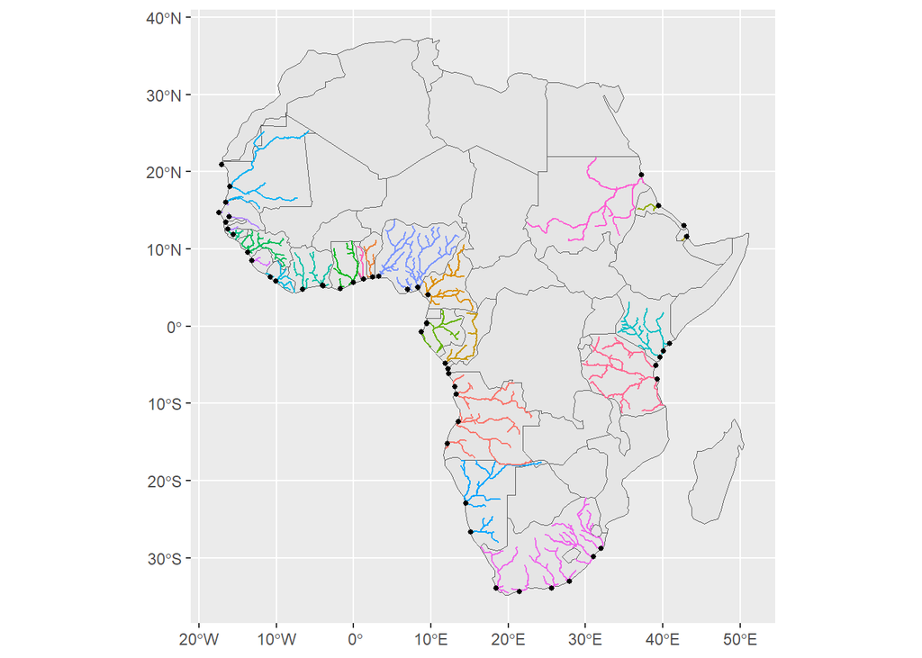

```r
ggplot()+
  geom_sf(data=sf.Africa)+
  geom_sf(data=results_sf,aes(colour=country),)+
  geom_sf(data=sf.africa_port_final%>%filter(name_long %in% maritime),colour="black",shape=19,size=1)+
  guides(colour = FALSE)
```

## Data preparation - nightlights

```r
# Polygon data of Africa
sf.Africa <- world%>%
  filter(continent=='Africa')

# Rename countries in sf.Africa so they match the Populated Places data
sf.Africa$name_long[sf.Africa$name_long == "Republic of the Congo"] <- "Congo (Brazzaville)"
sf.Africa$name_long[sf.Africa$name_long == "Côte d'Ivoire"] <- "Ivory Coast"
sf.Africa$name_long[sf.Africa$name_long == "Guinea-Bissau"] <- "Guinea Bissau"

# Load African cities and add buffer around each of them
sf.cities<-st_read("C:/Users/gatla/OneDrive/BSE/Geospatial/homework/homework3/ne_10m_populated_places/ne_10m_populated_places.shp")
sf.africa_cities <- st_intersection(sf.cities,sf.Africa) %>%
  st_buffer(dist=10000)%>%
  dplyr::select(NAME,ADM0NAME,ADM1NAME,POP_MAX)
# Define countries of interest
maritime <-c("Sudan", "Eritrea","Djibouti","Kenya", "Tanzania",
             "South Africa", "Namibia","Angola","Gabon","Congo (Brazzaville)","Cameroon",
             "Nigeria","Benin","Togo","Ghana","Ivory Coast","Liberia","Sierra Leone",
             "Guinea", "Guinea Bissau", "Senegal", "Mauritania")

non_agoa <-c("Tunisia", "Morocco") #for our pseudo trial
```

We filter our data into three seperate dataframes. One for our main econometrics analysis, one for the pseudo treatment analysis, and one at a country level for the nightlight v GDP comparison.

```r
# Below filters for maritime cities in AGOA
sf.agoa_cities<-sf.africa_cities%>%
  filter(ADM0NAME %in% maritime)

# Filter for non-agoa nations
sf.non_agoa_cities<-sf.africa_cities%>%
  filter(ADM0NAME %in% non_agoa)

# Filter africa data just by countries of interest
sf.Africa<-sf.Africa%>%
  filter(name_long %in% maritime)
```

We noticed there were two places called Middelburg in South Africa, so we rename them here.

```r
# There are two Middelburgs in South Africa - rename now so they can be matched correctly with distance data
subset_agoa <- subset(sf.agoa_cities, NAME == "Middelburg")
subset_agoa
```

```
## Simple feature collection with 2 features and 4 fields
## Geometry type: POLYGON
## Dimension:     XY
## Bounding box:  xmin: 24.90422 ymin: -31.59139 xmax: 29.57021 ymax: -25.66851
## Geodetic CRS:  WGS 84
##           NAME     ADM0NAME     ADM1NAME POP_MAX                       geometry
## 137 Middelburg South Africa   Mpumalanga  154706 POLYGON ((29.41648 -25.8372...
## 176 Middelburg South Africa Eastern Cape   18164 POLYGON ((25.09553 -31.5531...
```

```r
# Re-name manually based on the index
sf.agoa_cities[137, "NAME"] <- "Middelburg_mpu"
sf.agoa_cities[176, "NAME"] <- "Middelburg_ec"
```

Now we load in the nightlight data

```r
setwd("C:/Users/gatla/OneDrive/BSE/Geospatial/Final_project")
# Nightlight file paths here
file_paths <- c("F101992.v4/F101992.v4b_web.stable_lights.avg_vis.tif/F101992.v4b_web.stable_lights.avg_vis.tif",
                "F101993.v4/F101993.v4b_web.stable_lights.avg_vis.tif/F101993.v4b_web.stable_lights.avg_vis.tif",
                "F121994.v4/F121994.v4b_web.stable_lights.avg_vis.tif/F121994.v4b_web.stable_lights.avg_vis.tif",
                "F121995.v4/F121995.v4b_web.stable_lights.avg_vis.tif/F121995.v4b_web.stable_lights.avg_vis.tif",
                "F121996.v4/F121996.v4b_web.stable_lights.avg_vis.tif/F121996.v4b_web.stable_lights.avg_vis.tif",
                "F141997.v4/F141997.v4b_web.stable_lights.avg_vis.tif/F141997.v4b_web.stable_lights.avg_vis.tif",
                "F141998.v4/F141998.v4b_web.stable_lights.avg_vis.tif/F141998.v4b_web.stable_lights.avg_vis.tif",
                "F141999.v4/F141999.v4b_web.stable_lights.avg_vis.tif/F141999.v4b_web.stable_lights.avg_vis.tif",
                "F142000.v4/F142000.v4b_web.stable_lights.avg_vis.tif/F142000.v4b_web.stable_lights.avg_vis.tif",
                "F142001.v4/F142001.v4b_web.stable_lights.avg_vis.tif/F142001.v4b_web.stable_lights.avg_vis.tif",
                "F142002.v4/F142002.v4b_web.stable_lights.avg_vis.tif/F142002.v4b_web.stable_lights.avg_vis.tif",
                "F142003.v4/F142003.v4b_web.stable_lights.avg_vis.tif/F142003.v4b_web.stable_lights.avg_vis.tif",
                "F152004.v4/F152004.v4b_web.stable_lights.avg_vis.tif/F152004.v4b_web.stable_lights.avg_vis.tif",
                "F152005.v4/F152005.v4b_web.stable_lights.avg_vis.tif/F152005.v4b_web.stable_lights.avg_vis.tif",
                "F152006.v4/F152006.v4b_web.stable_lights.avg_vis.tif/F152006.v4b_web.stable_lights.avg_vis.tif",
                "F152007.v4/F152007.v4b_web.stable_lights.avg_vis.tif/F152007.v4b_web.stable_lights.avg_vis.tif",
                "F162008.v4/F162008.v4b_web.stable_lights.avg_vis.tif/F162008.v4b_web.stable_lights.avg_vis.tif",
                "F162009.v4/F162009.v4b_web.stable_lights.avg_vis.tif/F162009.v4b_web.stable_lights.avg_vis.tif",
                "F182010.v4/F182010.v4d_web.stable_lights.avg_vis.tif/F182010.v4d_web.stable_lights.avg_vis.tif",
                "F182011.v4/F182011.v4c_web.stable_lights.avg_vis.tif/F182011.v4c_web.stable_lights.avg_vis.tif",
                "F182012.v4/F182012.v4c_web.stable_lights.avg_vis.tif/F182012.v4c_web.stable_lights.avg_vis.tif",
                "F182013.v4/F182013.v4c_web.stable_lights.avg_vis.tif/F182013.v4c_web.stable_lights.avg_vis.tif")
```

Here we loop through nightlights for each year and extract the pixel sum of nightlights for each area.

```r
# Loop over file paths and extract sum of nightlights for each area
# For dataframe of agoa countries, non-agoa countries and at a country level for Africa dataframe
for (i in seq_along(file_paths)) {
  # Load raster
  r <- raster(file_paths[i])
  col_name <- paste0("nl_score_", 1991 + i)

  # Crop raster to Africa
  cropped_r <- crop(r, sf.Africa)

  r.zonal_ag <- exact_extract(
    x = cropped_r, # raster
    y = sf.agoa_cities, # polygon
    fun = 'sum') # statistic

  r.zonal_nag <- exact_extract(
    x = cropped_r, # raster
    y = sf.non_agoa_cities, # polygon
    fun = 'sum') # statistic

  r.zonal_af <- exact_extract(
    x = cropped_r, # raster
    y = sf.Africa, # polygon
    fun = 'sum') # statistic

  sf.agoa_cities[[col_name]] <- r.zonal_ag
  sf.non_agoa_cities[[col_name]] <- r.zonal_nag
  sf.Africa[[col_name]] <- r.zonal_af
}
```

[output not shown]

[output not shown]

[output not shown]

[output not shown]

[output not shown]

[output not shown]

[output not shown]

[output not shown]

[output not shown]

[output not shown]

[output not shown]

[output not shown]

[output not shown]

[output not shown]

[output not shown]

[output not shown]

[output not shown]

[output not shown]

[output not shown]

[output not shown]

[output not shown]

[output not shown]

[output not shown]

[output not shown]

[output not shown]

[output not shown]

[output not shown]

[output not shown]

[output not shown]

[output not shown]

[output not shown]

[output not shown]

[output not shown]

[output not shown]

[output not shown]

[output not shown]

[output not shown]

[output not shown]

[output not shown]

[output not shown]

[output not shown]

[output not shown]

[output not shown]

[output not shown]

```r
# Drop geometry
agoa_cities <- st_drop_geometry(sf.agoa_cities)
non_agoa_cities <- st_drop_geometry(sf.non_agoa_cities)
africa <- st_drop_geometry(sf.Africa)
```

Our data is currently in wide format, but for our analysis it is most useful for it to be in long fomat, so we pivot the data here.

```r
# Convert data to long format
agoa_cities_long <- agoa_cities %>%
  pivot_longer(cols = starts_with("nl_score"),
               names_to = "year",
               values_to = "nl_score")%>%
  mutate(year = gsub("nl_score_", "", year))

non_agoa_cities_long <- non_agoa_cities %>%
  pivot_longer(cols = starts_with("nl_score"),
               names_to = "year",
               values_to = "nl_score")%>%
  mutate(year = gsub("nl_score_", "", year))

africa_long <- africa %>%
  pivot_longer(cols = starts_with("nl_score"),
               names_to = "year",
               values_to = "nl_score")%>%
  mutate(year = gsub("nl_score_", "", year))

# Convert year to numeric
agoa_cities_long$year <- as.numeric(agoa_cities_long$year)
non_agoa_cities_long$year <- as.numeric(non_agoa_cities_long$year)
```

## Nightlight v GDP comparison

```r
# Load GDP data
setwd("C:/Users/gatla/OneDrive/BSE/Geospatial/Final_project/")
gdp <- read.csv("API_NY.GDP.MKTP.CD_DS2_en_csv_v2_2/API_NY.GDP.MKTP.CD_DS2_en_csv_v2_2.csv", skip = 4)

# Drop unwanted cols
gdp <- subset(gdp, select = -c(Country.Code, Indicator.Name, Indicator.Code))

# Change country names in GDP data so they match with Africa country data
gdp$Country.Name[gdp$Country.Name == "Congo, Rep."] <- "Congo (Brazzaville)"
gdp$Country.Name[gdp$Country.Name == "Cote d'Ivoire"] <- "Ivory Coast"
gdp$Country.Name[gdp$Country.Name == "Guinea-Bissau"] <- "Guinea Bissau"

# Reshape to long
gdp_long <- gdp %>%
  pivot_longer(cols = starts_with("X"),
               names_to = "year",
               values_to = "GDP") %>%
  mutate(year = gsub("X", "", year))

# Merge with Africa country data
africa_long_gdp <- inner_join(africa_long, gdp_long, by=c("name_long"="Country.Name", "year"))
```

Plot the trend of nightlights and GDP for each country. Note we stadardise the GDP and nightlights at a country level for this comparison.

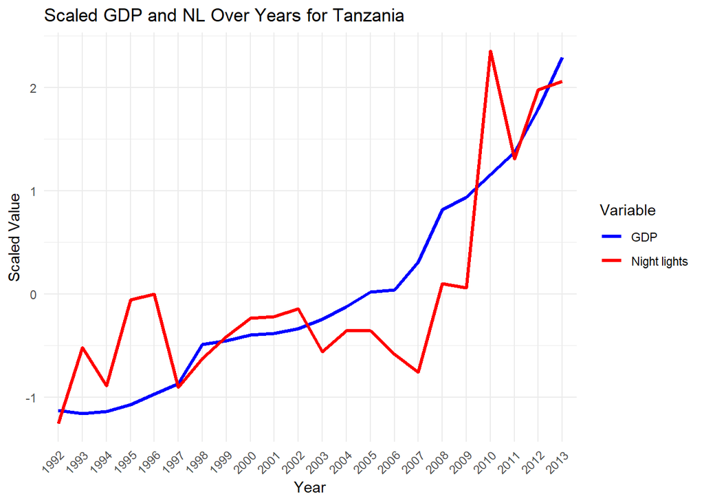

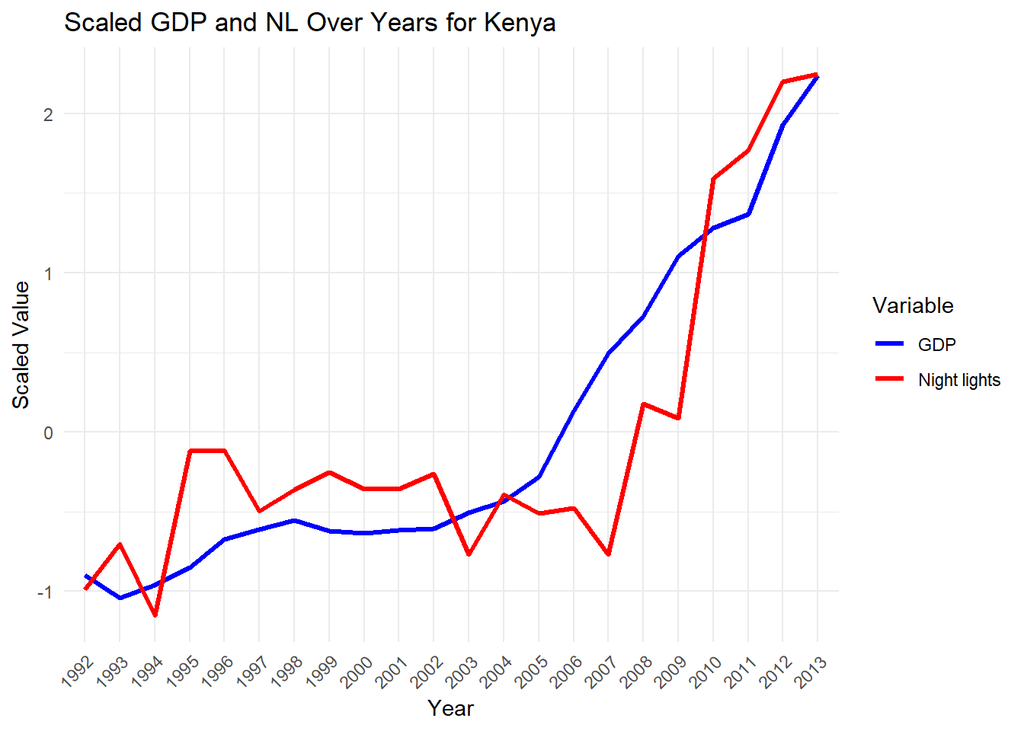

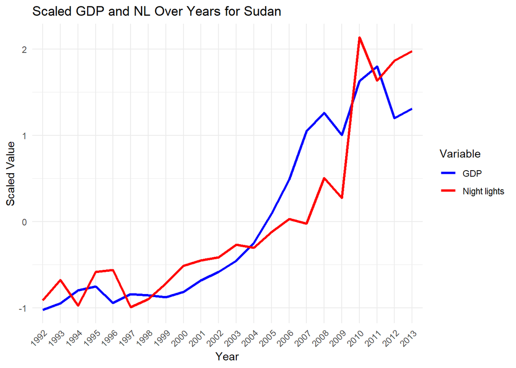

```
##
## $`South Africa`
```

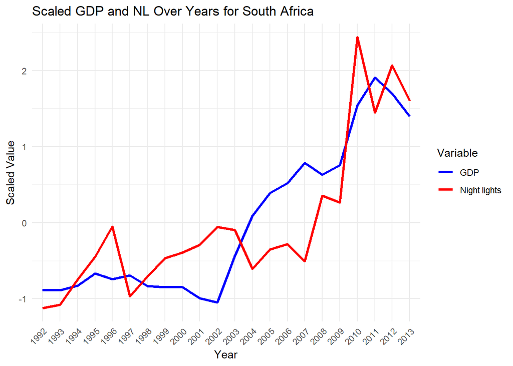

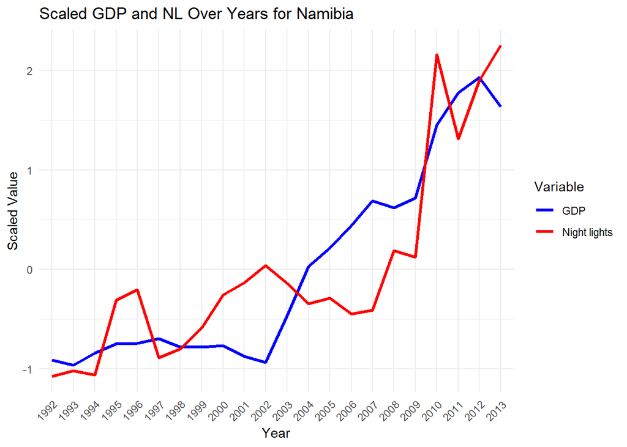

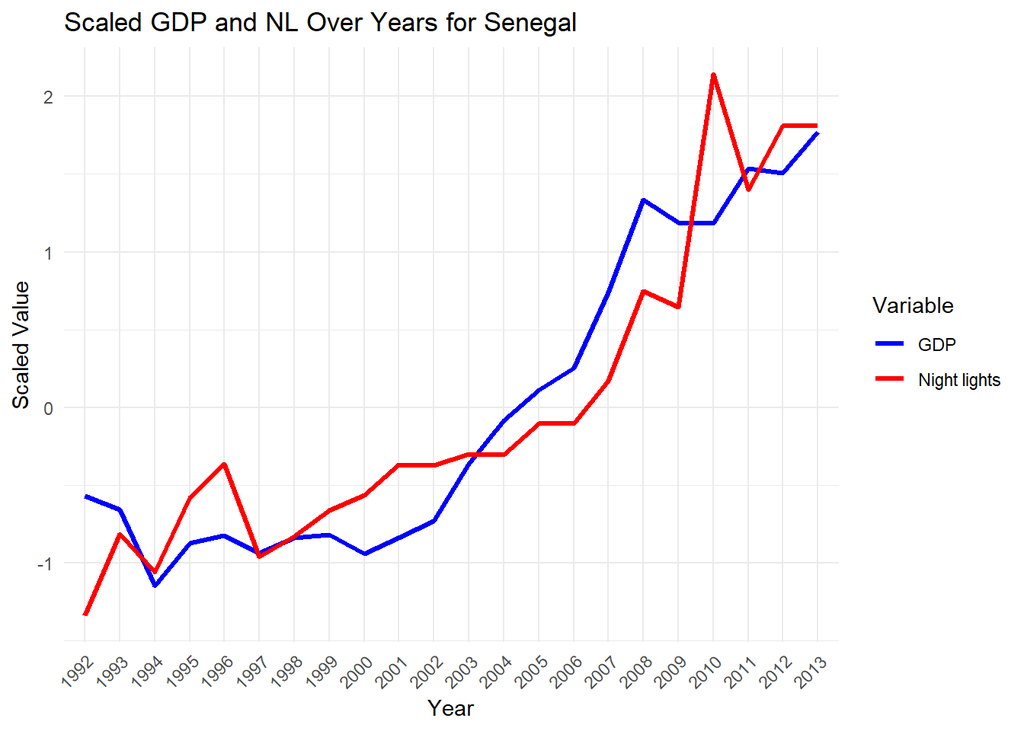

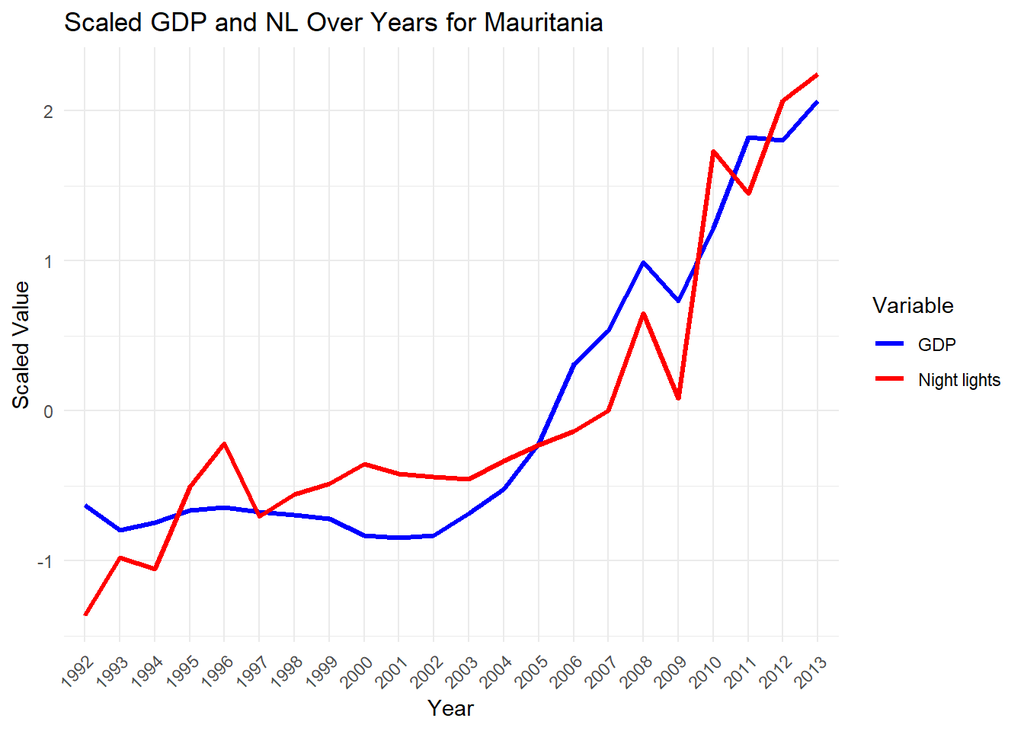

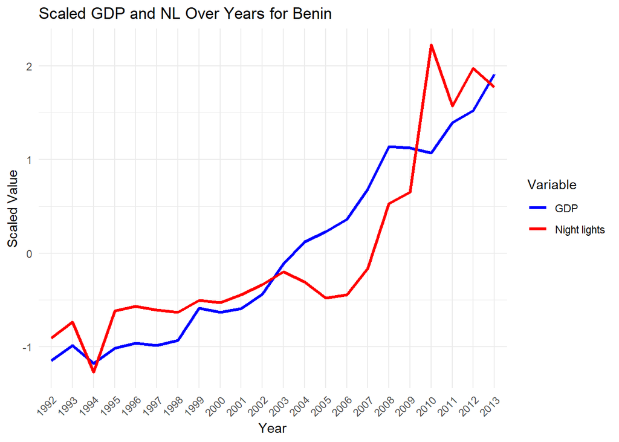

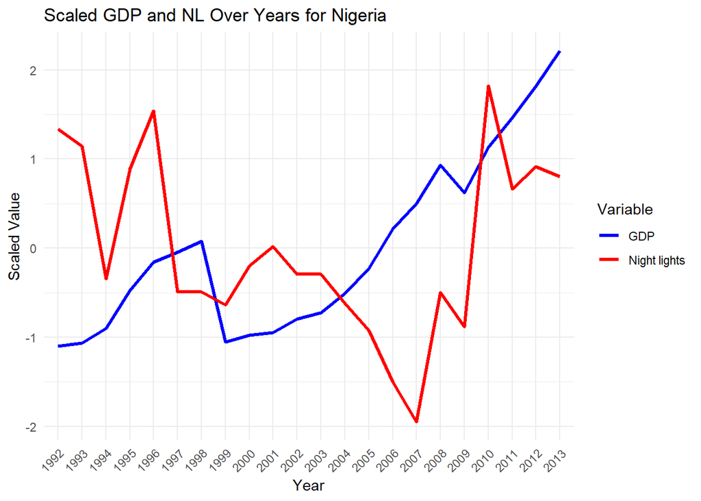

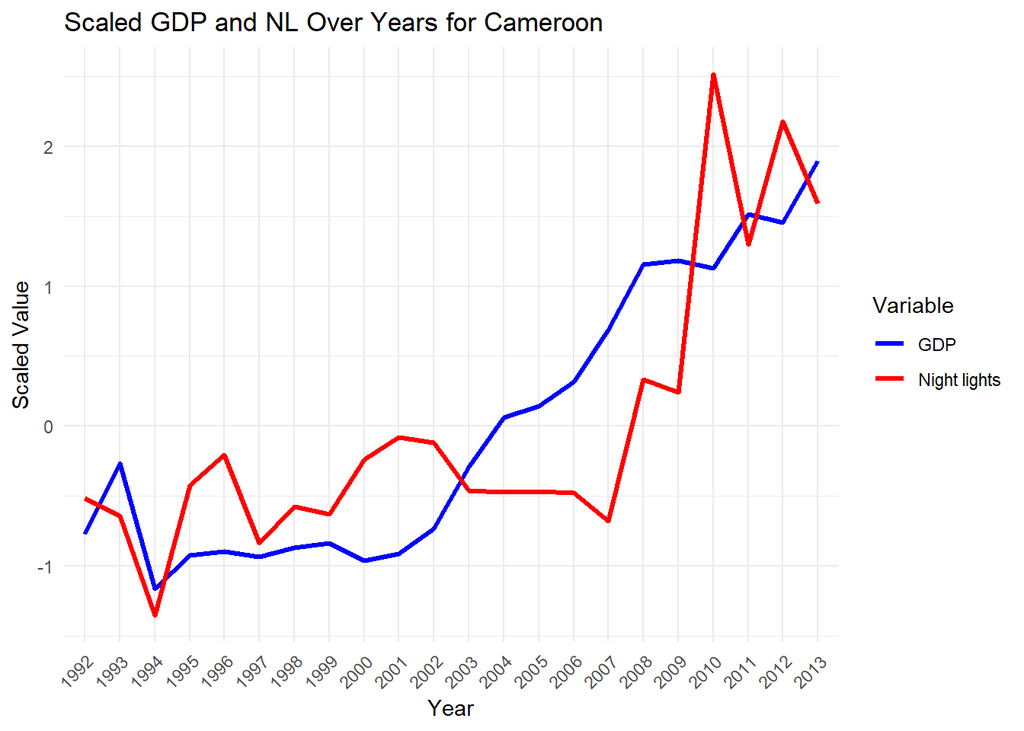

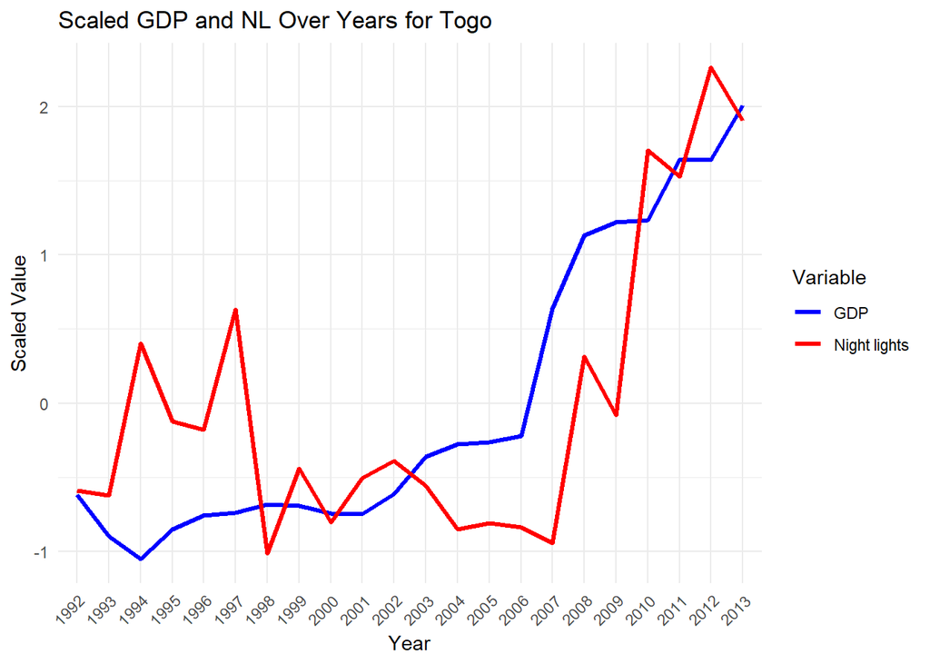

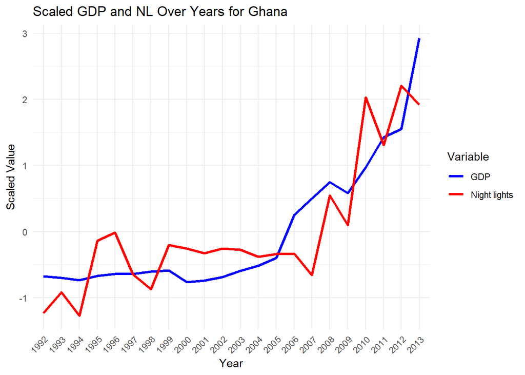

```
##
## $`Ivory Coast`
```

[10 more figures not shown]

```r
# Plotting trends for each country
unique_countries <- unique(africa_long_gdp$name_long)

plots_list <- list()

# Loop through each country
for (country_name in unique_countries) {
  # Subset data for current country
  country_data <- africa_long_gdp %>%
    filter(name_long == country_name)

  # Scale country data
  country_data$GDP_scale <- scale(country_data$GDP)
  country_data$nl_scale <- scale(country_data$nl_score)

  # Create the plot for the current country
  plot <- ggplot(country_data, aes(x = year)) +
    geom_line(aes(y = GDP_scale, group=1, color = "GDP Scale"), size = 1.2) +
    geom_line(aes(y = nl_scale, group=1, color = "NL Scale"), size = 1.2) +
    labs(x = "Year", y = "Scaled Value", color = "Variable",
         title = paste("Scaled GDP and NL Over Years for", country_name)) +
    theme_minimal() +
    theme(axis.text.x = element_text(angle = 45, hjust = 1)) +
    scale_color_manual(values = c("blue", "red"),
                       labels = c("GDP", "Night lights"))

  # Store the plot in the list
  plots_list[[country_name]] <- plot
}
plots_list
```

## Econometrics

```r
# Manually add AGOA variable for each country depending on when they joined the agreement
agoa_cities_long <- agoa_cities_long %>%
  mutate(AGOA = 0)%>%
  mutate(AGOA = if_else(ADM0NAME == "Sudan" & year>2000, 1, AGOA))%>%
  mutate(AGOA = if_else(ADM0NAME == "Eritrea" & year>2000, 1, AGOA))%>%
  mutate(AGOA = if_else(ADM0NAME == "Eritrea" & year>2003, 0, AGOA))%>%
  mutate(AGOA = if_else(ADM0NAME == "Djibouti" & year>2000, 1, AGOA))%>%
  mutate(AGOA = if_else(ADM0NAME == "Kenya" & year>2000, 1, AGOA))%>%
  mutate(AGOA = if_else(ADM0NAME == "Tanzania" & year>2000, 1, AGOA))%>%
  mutate(AGOA = if_else(ADM0NAME == "South Africa" & year>2000, 1, AGOA))%>%
  mutate(AGOA = if_else(ADM0NAME == "Namibia" & year>2000, 1, AGOA))%>%
  mutate(AGOA = if_else(ADM0NAME == "Angola" & year>2003, 1, AGOA))%>%
  mutate(AGOA = if_else(ADM0NAME == "Gabon" & year>2000, 1, AGOA))%>%
  mutate(AGOA = if_else(ADM0NAME == "Congo (Brazzaville)" & year>2000, 1, AGOA))%>%
  mutate(AGOA = if_else(ADM0NAME == "Cameroon" & year>2000, 1, AGOA))%>%
  mutate(AGOA = if_else(ADM0NAME == "Nigeria" & year>2000, 1, AGOA))%>%
  mutate(AGOA = if_else(ADM0NAME == "Nigeria" & year==2010, 0, AGOA))%>%
  mutate(AGOA = if_else(ADM0NAME == "Nigeria" & year==2011, 0, AGOA))%>%
  mutate(AGOA = if_else(ADM0NAME == "Benin" & year>2000, 1, AGOA))%>%
  mutate(AGOA = if_else(ADM0NAME == "Togo" & year>2008, 1, AGOA))%>%
  mutate(AGOA = if_else(ADM0NAME == "Ghana" & year>2000, 1, AGOA))%>%
  mutate(AGOA = if_else(ADM0NAME == "Ivory Coast" & year>2011, 1, AGOA))%>%
  mutate(AGOA = if_else(ADM0NAME == "Liberia" & year>2006, 1, AGOA))%>%
  mutate(AGOA = if_else(ADM0NAME == "Sierra Leone" & year>2002, 1, AGOA))%>%
  mutate(AGOA = if_else(ADM0NAME == "Guinea" & year>2000, 1, AGOA))%>%
  mutate(AGOA = if_else(ADM0NAME == "Guinea" & year==2010, 0, AGOA))%>%
  mutate(AGOA = if_else(ADM0NAME == "Guinea" & year==2011, 0, AGOA))%>%
  mutate(AGOA = if_else(ADM0NAME == "Guinea Bissau" & year>2000, 1, AGOA))%>%
  mutate(AGOA = if_else(ADM0NAME == "The Gambia" & year>2000, 1, AGOA))%>%
  mutate(AGOA = if_else(ADM0NAME == "Senegal" & year>2000, 1, AGOA))%>%
  mutate(AGOA = if_else(ADM0NAME == "Mauritania" & year>2000, 1, AGOA))%>%
  mutate(AGOA = if_else(ADM0NAME == "Mauritania" & year==2007, 0, AGOA))%>%
  mutate(AGOA = if_else(ADM0NAME == "Mauritania" & year==2008, 0, AGOA))


# For non-agoa countries, add fake entry after 2000 for all
non_agoa_cities_long <- non_agoa_cities_long %>%
  mutate(AGOA = 0)%>%
  mutate(AGOA = if_else(year>2000, 1, AGOA))
```

```r
# Loading the distance to nearest port (constructed in the distance markdown file)
distance <- read.csv("distance_data/AFRICA_COAST_weights.csv")
distance_nonag <- read.csv("distance_data/AFRICA_COAST_weights_non_agoa.csv")

# Adjusting Middelburg in the distance data
subset_distance <- subset(distance, city == "Middelburg")
subset_distance
```

```
##           city      country min_dist
## 148 Middelburg South Africa 522775.5
## 192 Middelburg South Africa 323736.6
## 193 Middelburg South Africa 323736.6
```

```r
# Manually rename and remove duplicates
distance[148, "city"] <- "Middelburg_mpu"
distance[192, "city"] <- "Middelburg_ec"
distance <- distance[-193, ]
```

Where we created the distance variable we had some issues of cities being duplicated, so we remove those here. Also, some cities which were close to country borders were assigned to the wrong country leading to some discrepancies in the cities included between the distance data and the nightlights data. Here we remove any settlements that don’t appear in both datasets.

```r
# Check the number of matching city names
unique_cities_agoa <- unique(agoa_cities_long$NAME)
unique_cities_distance <- unique(distance$city)

unique_to_agoa <- setdiff(unique_cities_agoa, unique_cities_distance)
unique_to_distance <- setdiff(unique_cities_distance, unique_cities_agoa)

unique_to_agoa
```

```
## [1] "Impfondo"    "Luau"        "Brazzaville" "Tunduma"     "Komatipoort"
## [6] "Moyale"
```

```r
unique_to_distance
```

```
## [1] "Butha-Buthe"  "Beitbridge"   "Golela"       "Sesheke"      "Mongomo"
## [6] "Birni Nkonni"
```

```r
# Remove any cities that don't appear in both dataframes
agoa_cities_long_filter <- subset(agoa_cities_long, !(NAME %in% unique_to_agoa))
distance_filter <- subset(distance, !(city %in% unique_to_distance))

# Check for duplicates in distance
duplicates <- duplicated(distance_filter$city)
duplicated_rows <- distance_filter[duplicates, ]

# Remove duplicated cities from distance dataframe
distance_filter_unique <- unique(distance_filter)
```

We now repeat similar steps to the above with the non-agoa countries (Here lots more will be dropped as we are only focusing on TUnisia and Morocco).

```r
# Check the number of matching city names - non agoa data
unique_cities_non_agoa <- unique(non_agoa_cities_long$NAME)
unique_cities_distance_nonag <- unique(distance_nonag$city)

unique_to_non_agoa <- setdiff(unique_cities_non_agoa, unique_cities_distance_nonag)
unique_to_distance_nonag <- setdiff(unique_cities_distance_nonag, unique_cities_non_agoa)

unique_to_non_agoa
```

```
## character(0)
```

```r
unique_to_distance_nonag
```

```
##   [1] "Dirj"               "Nalut"              "Zillah"
##   [4] "Tajarhi"            "Umm al Abid"        "Az Zawiyah"
##   [7] "Gharyan"            "Mizdah"             "Bani Walid"
##  [10] "Al Marj"            "Al Bayda"           "El Agheila"
##  [13] "Maradah"            "Qaminis"            "Al Jaghbub"
##  [16] "Salum"              "Hun"                "Birak"
##  [19] "Ghat"               "Marzuq"             "Ajdabiya"
##  [22] "Awjilah"            "Al Jawf"            "Tmassa"
##  [25] "Zuwara"             "Sabha"              "Banghazi"
##  [28] "Jijel"              "Tizi-Ouzou"         "Bordj Bou Arréridj"
##  [31] "M'sila"             "Guelma"             "Oum el Bouaghi"
##  [34] "Timimoun"           "Sidi bel Abbes"     "Tlimcen"
##  [37] "Béni Ounif"         "Abadla"             "Sefra"
##  [40] "Skikda"             "Djanet"             "I-n-Amenas"
##  [43] "In Amguel"          "El Bayadh"          "El Oued"
```

[output cut: 42 more lines]

```r
# Remove any cities that don't appear in both dataframes
non_agoa_cities_long_filter <- subset(non_agoa_cities_long, !(NAME %in% unique_to_non_agoa))
```

Merge distance and nightlight data

```r
# Merge distance data
merged_df <- inner_join(agoa_cities_long_filter, distance_filter_unique, by = c("NAME" = "city"))

merged_nonag <- inner_join(non_agoa_cities_long_filter, distance_nonag, by = c("NAME" = "city"))


# Convert country variable to dummy in both dataframes
merged_df$country <- as.factor(merged_df$country)
merged_nonag$country <- as.factor(merged_nonag$country)
```

Below we run our different econometric specifications

```r
# Regressions - baseline
model_base <- lm(nl_score ~ AGOA + min_dist + AGOA:min_dist, data = merged_df)

model_pop <- lm(nl_score ~ AGOA + min_dist + AGOA:min_dist + POP_MAX, data = merged_df)

model_pop_country <- lm(nl_score ~ AGOA + min_dist + AGOA:min_dist + POP_MAX + country, data = merged_df)

model_country_year <- lm(nl_score ~ AGOA + min_dist + AGOA:min_dist + POP_MAX + country:year, data = merged_df)


stargazer(model_base, model_pop, model_pop_country, model_country_year, type = "text", title = "Regression Results",
          omit="country",
          align = TRUE, # Align coefficients
          column.labels = c("Baseline", "Population", "Country dummies", "Year dummies"),
          covariate.labels = c("AGOA" = "AGOA",
                               "min_dist" = "Distance",
                               "POP_MAX" = "Population",
                               "AGOA:min_dist" = "AGOA Distance Interaction"),
          dep.var.labels = "Night lights")
```

```
##
## Regression Results
## ========================================================================================================================================
##                                                                        Dependent variable:
##                           --------------------------------------------------------------------------------------------------------------
##                                                                            Night lights
##                                   Baseline                   Population                Country dummies              Year dummies
##                                      (1)                        (2)                          (3)                         (4)
## ----------------------------------------------------------------------------------------------------------------------------------------
## AGOA                             661.474***                  701.613***                  485.024***                  -271.675***
##                                   (118.584)                   (86.921)                    (76.825)                    (95.483)
##
## Distance                          -0.001***                  -0.0004***                   -0.001***                   -0.001***
##                                   (0.0001)                    (0.0001)                    (0.0001)                    (0.0001)
##
## Population                                                    0.004***                    0.004***                    0.004***
##                                                              (0.00004)                    (0.00003)                   (0.00003)
##
## AGOA Distance Interaction          -0.0002                   -0.0003**                    -0.0002*                    -0.0002*
##                                   (0.0002)                    (0.0001)                    (0.0001)                    (0.0001)
##
## Constant                        2,538.450***                1,147.035***                 754.100***                -148,136.300***
##                                   (84.011)                    (63.114)                    (93.646)                  (11,350.830)
##
## ----------------------------------------------------------------------------------------------------------------------------------------
## Observations                       11,748                      11,748                      11,748                      11,748
## R2                                  0.022                      0.475                        0.619                       0.624
## Adjusted R2                         0.022                      0.474                        0.618                       0.623
## Residual Std. Error        3,952.455 (df = 11744)      2,897.081 (df = 11743)      2,470.355 (df = 11722)      2,452.223 (df = 11721)
## F Statistic               87.305*** (df = 3; 11744) 2,650.854*** (df = 4; 11743) 760.455*** (df = 25; 11722) 748.791*** (df = 26; 11721)
## ========================================================================================================================================
## Note:                                                                                                        *p<0.1; **p<0.05; ***p<0.01
```

```r
# Other specifications
merged_df_filtered <- merged_df[merged_df$nl_score != 0, ]
merged_df_cities <- merged_df_filtered[merged_df_filtered$POP_MAX > 50000, ]
merged_df_non_port <- merged_df[merged_df$min_dist > 1000, ]

baseline <- lm(nl_score ~ AGOA + min_dist + AGOA:min_dist + POP_MAX + country:year, data = merged_df)
big_cities <- lm(nl_score ~ AGOA + min_dist + AGOA:min_dist + POP_MAX + country:year, data = merged_df_cities)
non_port <- lm(nl_score ~ AGOA + min_dist + AGOA:min_dist + POP_MAX + country:year, data = merged_df_non_port)
pseudo <- lm(nl_score ~ AGOA + min_dist + AGOA:min_dist + POP_MAX + country:year, data = merged_nonag)


stargazer(baseline, big_cities, non_port, pseudo, type = "text", title = "Regression Results",
          omit="country",
          align = TRUE, # Align coefficients
          column.labels = c("Baseline", "Cities", "Non coastal", "Pseudo"),
          covariate.labels = c("AGOA" = "AGOA",
                               "min_dist" = "Distance",
                               "POP_MAX" = "Population",
                               "AGOA:min_dist" = "AGOA Distance Interaction"),
          dep.var.labels = "Night lights")
```

```
##
## Regression Results
## =====================================================================================================================================
##                                                                       Dependent variable:
##                           -----------------------------------------------------------------------------------------------------------
##                                                                          Night lights
##                                    Baseline                     Cities                   Non coastal                  Pseudo
##                                       (1)                        (2)                         (3)                       (4)
## -------------------------------------------------------------------------------------------------------------------------------------
## AGOA                              -271.675***                 -372.824**                 -286.638***                 -126.541
##                                    (95.483)                   (147.191)                   (97.598)                  (122.128)
##
## Distance                           -0.001***                  -0.001***                   -0.001***                  0.001***
##                                    (0.0001)                    (0.0002)                   (0.0001)                   (0.0002)
##
## Population                         0.004***                    0.003***                   0.004***                   -0.0001
##                                    (0.00003)                  (0.00004)                   (0.00004)                 (0.00005)
##
## AGOA Distance Interaction          -0.0002*                   -0.0004**                    -0.0002                    0.0003
##                                    (0.0001)                    (0.0002)                   (0.0001)                   (0.0003)
##
## Constant                        -148,136.300***            -214,893.900***             -146,250.200***             -27,809.980*
##                                  (11,350.830)                (17,737.990)               (11,476.070)               (15,515.590)
##
## -------------------------------------------------------------------------------------------------------------------------------------
## Observations                        11,748                      5,983                      11,506                     1,012
## R2                                   0.624                      0.671                       0.616                     0.109
## Adjusted R2                          0.623                      0.670                       0.615                     0.104
## Residual Std. Error         2,452.223 (df = 11721)      2,878.134 (df = 5957)      2,450.699 (df = 11479)      820.143 (df = 1005)
## F Statistic               748.791*** (df = 26; 11721) 486.309*** (df = 25; 5957) 708.062*** (df = 26; 11479) 20.484*** (df = 6; 1005)
## =====================================================================================================================================
## Note:                                                                                                     *p<0.1; **p<0.05; ***p<0.01
```